# Practice Activity 3: Data Wrangling with dplyr 🏫

Today you will be using the dplyr package to clean a dataset and then using that cleaned dataset to figure out what college Ephelia has been accepted to.

## 0.1 Dealing with errors

As you work through this PA, you will encounter some code that does not work as you want it to. Don’t despair! Errors (when R is unable to run your code) and bugs (when the code doesn’t do what you hoped) are a natural part of coding. Even the best of the best deal with these problems regularly - learning to track down the issue is a skill that you can learn and practice.

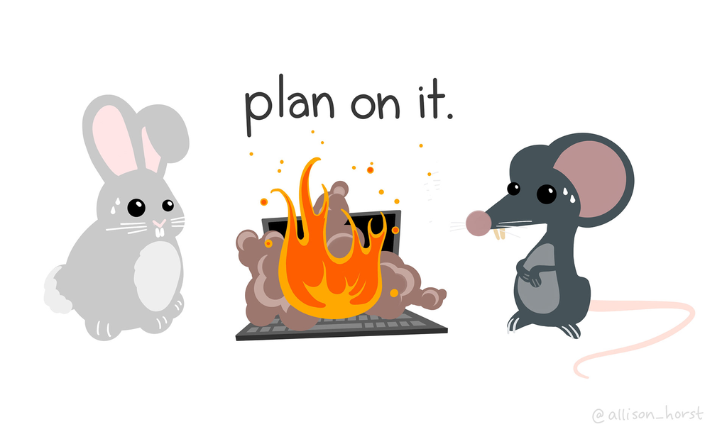

Image by Allison Horst

**Advice for dealing with errors**

**Errors can be sneaky - check results *often***

If a chunk of code runs smoothly without giving you any error or warnings this **does not** necessarily mean it accomplished the desired task.

It is a good habit to check the results of your code **every time** you finish a task. In general, I would recommend completing the following tasks **every time** you write a code chunk.

- Include a comment at the beginning of the code chunk that briefly states what the purpose of the chunk is. Comments in the code chunks come after `#` signs. These comments will remind later readers—which might be your future self!—what the desired output of the code chunk is.
- If you created a new object, take a look at it! You can inspect the object by either clicking its name in your *Environment* tab or by typing its name into the console. Make sure it looks about how you expect. **Do not** type code to inspect the object in your Quarto file, as that **is not** code that needs to be saved!
- If you created or updated a data frame, make sure your edits did what you hoped. Use the *Environment* or the `head()` and `glimpse()` functions to investigate your changes.

**Two heads are better than one**

It can be hard to spot bugs in code that you wrote.

Work with those around you - if something goes wrong, ask a friend or team member to take a peek at your code and see if any glaring errors (like *syntax error*) pop out.

**Explain your code out loud**

The best way to troubleshoot a sneaky but is to explain out loud each step of your code, and what you hoped to accomplish.

Schedule a meeting with your team to have everyone talk through their code.

If you are alone, try [Rubber Duck Debugging](https://en.wikipedia.org/wiki/Rubber_duck_debugging)!

**Google is your friend**

The whole of the internet is at your disposal! Use it early, use it often.

Some tricks:

- Copy-paste the exact error message into Google. Chances are, somebody else had a similar problem and got a similar message.
- Include package names in your search terms. For example, “bar plot in ggplot” is a better search than “bar plot in R”.

# 1 Part One: Data import and cleaning

## 1.1 Access the PA3 Quarto file

First, the individual appointed the “Reporter” for the team should [access the Practice Activity through through Posit Cloud](https://posit.cloud/content/5280164).

Once you have the Practice Activity open, click on the `PA3_student.qmd` file to open the Practice Activity 3 Quarto file.

## 1.2 Data download & packages

**Reading in data**

Note that the data loading function `read_csv()` will give you an outpouring of helpful information about the dataset. If you do not see the word “error”, there is nothing to be concerned about.

```r
library(tidyverse)

colleges <- read_csv("https://www.dropbox.com/s/bt5hvctdevhbq6j/colleges.csv?dl=1")
```

## 1.3 Data cleaning

Now we will clean the data. Alas, each of the R chunks in this section will cause an error and / or do the desired task incorrectly. Even the chunks that run without error **are not** correct! You will need to find the mistake and correct it to complete the intended action.

**Step 1:** There are too many variables in this dataset. We don’t need all of them. Narrow your dataset down to only:

- Name of the institution
- City, State, and ZIP code of the institution
- The Admissions Rate
- The average SAT score
- The number of undergraduate students
- The in and out of state tuition
- Whether the school is public or private
- The “REGION” variable.

```r
colleges_clean <- colleges | >
  select(INSTNM, CITY, STABBR, ZIP,
         ADM_RATE, SAT_AVG, UGDS,
         TUITIONFEE_IN, TUITIONFEE_OUT,
         CONTROL, REGION)
```

**Step 2:** Remove the schools that are private and for-profit (category 3).

```r
colleges_clean <- colleges_clean |>
  filter(CONTROL == 1, CONTROL == 2)
```

**Step 4:** Adjust the appropriate variables to be numeric.

```r
colleges_clean <- colleges_clean |>
  mutate(
    TUITIONFEE_IN = numeric(TUITIONFEE_IN),
    TUITIONFEE_OUT = numeric(TUITIONFEE_OUT),
    SAT_AVG = numeric(SAT_AVG),
    ADM_RATE = numeric(ADM_RATE)
    )
```

**Step 5:** Adjust the appropriate variables to be factors.

```r
colleges_clean |>
  mutate(
    CONTROL = as.factor(CONTROL),
    REGION = as.factor(REGION)
)
```

**Step 6:** Create a new variable called `TUITION_DIFF` which contains the difference between in and out of state costs.

```r
colleges_clean <- colleges_clean |>
    TUITION_DIFF = TUITIONFEE_OUT - TUITIONFEE_IN
```

**Step 7:** Remove every row with missing data.

```r
colleges_clean <- colleges_clean |>
  drop.na()
```

**Note**

This is not always a great idea! Usually, even if *some* of the information is missing, we don’t want to throw out the entire row. This time, however, we’ll be lazy.

**Notice that each of these steps started with:**

```r
colleges_clean <- colleges_clean |> ...
```

That is pretty redundant! Instead, we could perform all these tasks as one long “pipeline.”

**Step 8:** Combine your (fixed) code chunks into a **single** code chunk that carries out all of the steps necessary to clean the data.

**Tip**

Think about coding efficiency – you **should not** have multiple calls to the **same** function!

# 2 Part Two: Identify the mystery college

Wow! Your best friend Ephelia has been accepted to her top choice college! Unfortunately, Ephelia is a very mysterious person, and they won’t tell you directly which college this is. You’ll have to use their clues to figure out which school is their dream school.

Clues:

1. This college is located in Region 7.
2. This college’s admission rate is above the median rate for the region.
3. This college **does not** charge the same for in- and out-of-state tuition.
4. The average SAT score of this college is an odd number.
5. This college **is not** in Idaho.
6. Less than 1,000 people apply to this college every year. (Assume the size of the first year class is 1/4 of the undergraduate population.)
7. The college **is not** in the state where Dr. Theobold received a Ph.D.
8. Of the three options remaining at this step, Ephelia will attend the cheapest one.